# Week 1

Group 2

2/3/2022

## Data Cleaning

Dropped 4 missing value, their IDs are MC381,MC389,MC393,MC76.

## EDA

In this plot, we compared specific isotopes level in 4 taxon. It showed the level of d15N_air is less diverse than other 2 isotopes.

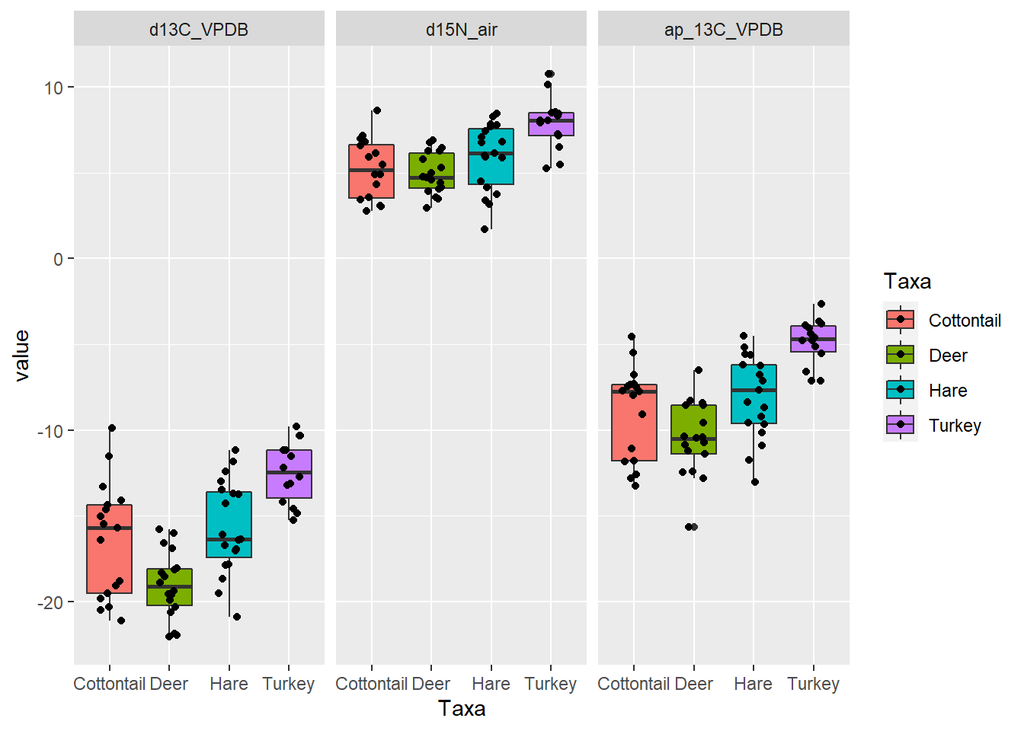

Then we compared isotopes in two sites for each kind of animals. The plot shows that the median level of d13C_VPDB and d15N_air in BAOX is higher than Tlajinga of cottontail. Similarly, the median level of d13C_VPDB and d15N_air of hare also show difference in the boxplot.

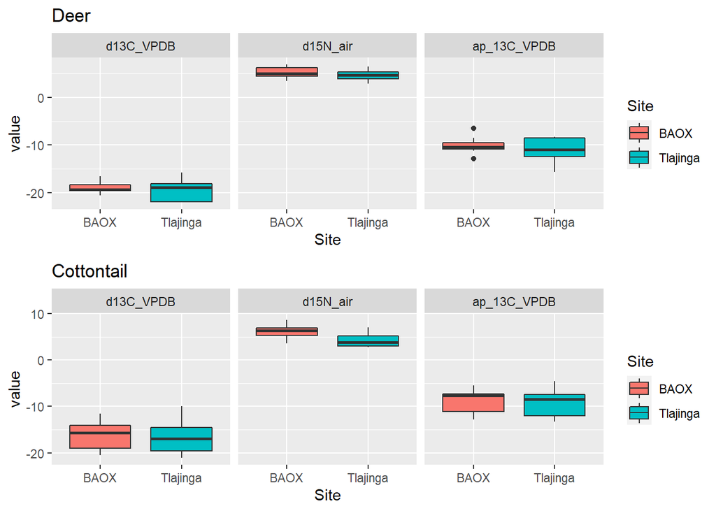

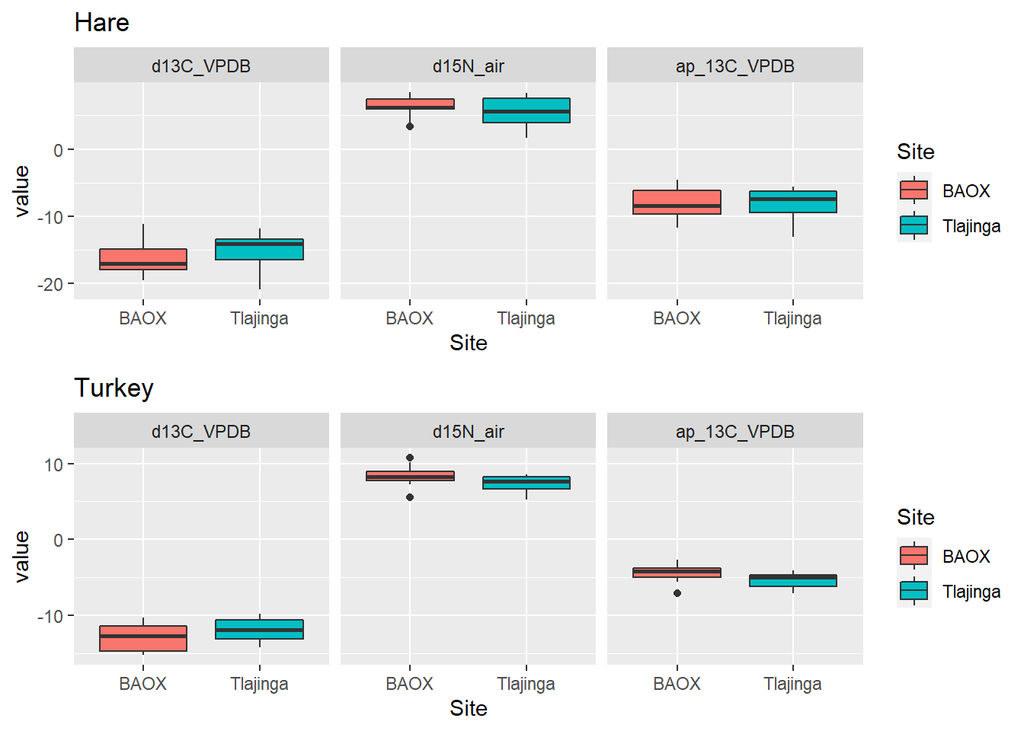

### Check Outlier

```r
mean(filter(aggdata,Taxa=="Hare" & Site=="BAOX" & variable=="d15N_air")$value)
```

```
## [1] 6.276364
```

```r
sd(filter(aggdata,Taxa=="Hare" & Site=="BAOX" & variable=="d15N_air")$value)
```

```
## [1] 1.582891
```

outlier falls on mean +- 2sd, we believe it is not a outlier.

## Density Test

We would like to use the T-tests to find the difference of diets between two sites.

Firstly, we checked the normality.

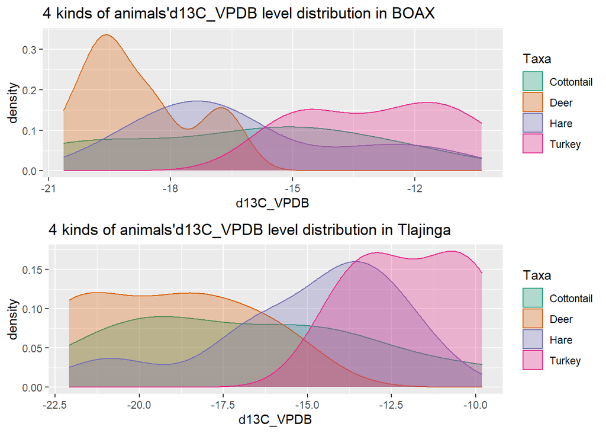

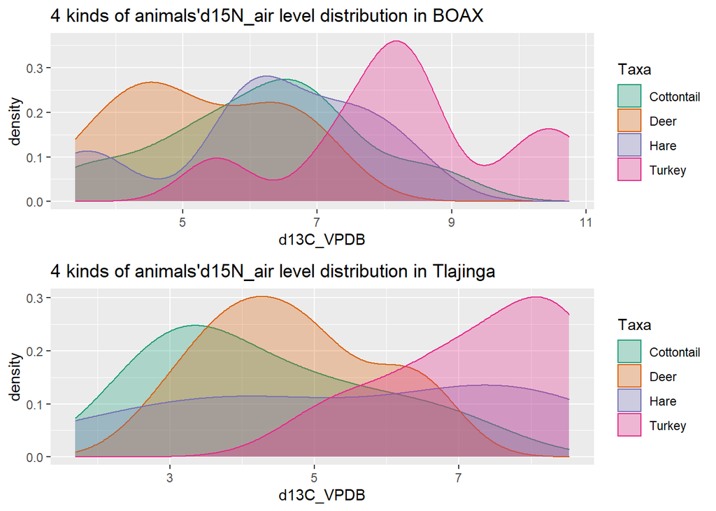

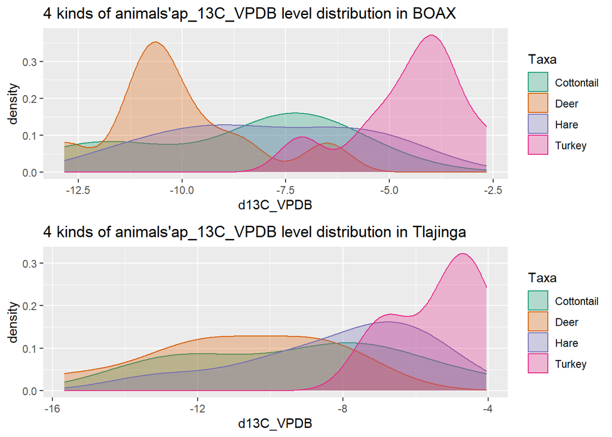

- Normal Distribution Test (Q-Q Plot)

Take “Turkey” and “d15N_air” as an example:

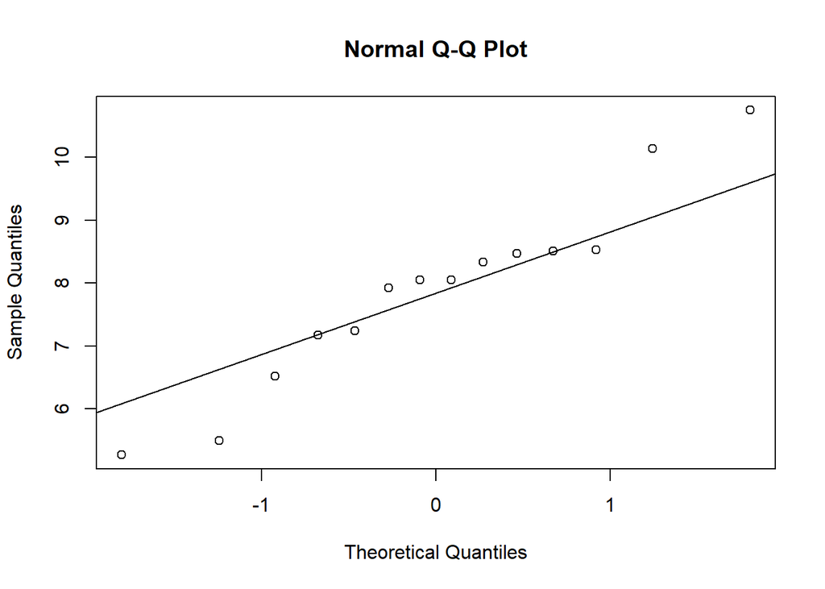

## Mann Whitney U Test

Mann-Whitney U Test for deer.

```
##
##  Wilcoxon rank sum exact test
##
## data:  value by Site
## W = 43, p-value = 0.8633
## alternative hypothesis: true location shift is not equal to 0
```

```
##
##  Wilcoxon rank sum exact test
##
## data:  value by Site
## W = 41, p-value = 0.673
## alternative hypothesis: true location shift is not equal to 0
```

```
##
##  Wilcoxon rank sum test with continuity correction
##
## data:  value by Site
## W = 51.5, p-value = 0.3536
## alternative hypothesis: true location shift is not equal to 0
```

Mann-Whitney U Test for Cottontail.

```
##
##  Wilcoxon rank sum exact test
##
## data:  value by Site
## W = 38, p-value = 0.8884
## alternative hypothesis: true location shift is not equal to 0
```

```
##
##  Wilcoxon rank sum exact test
##
## data:  value by Site
## W = 43, p-value = 0.5414
## alternative hypothesis: true location shift is not equal to 0
```

```
##
##  Wilcoxon rank sum exact test
##
## data:  value by Site
## W = 52, p-value = 0.03792
## alternative hypothesis: true location shift is not equal to 0
```

Mann-Whitney U Test for Hare.

```
##
##  Wilcoxon rank sum exact test
##
## data:  value by Site
## W = 32, p-value = 0.3511
## alternative hypothesis: true location shift is not equal to 0
```

```
##
##  Wilcoxon rank sum test with continuity correction
##
## data:  value by Site
## W = 45, p-value = 0.9671
## alternative hypothesis: true location shift is not equal to 0
```

```
##
##  Wilcoxon rank sum exact test
##
## data:  value by Site
## W = 50, p-value = 0.6574
## alternative hypothesis: true location shift is not equal to 0
```

Mann-Whitney U Test for Turkey.

```
##
##  Wilcoxon rank sum test with continuity correction
##
## data:  value by Site
## W = 15.5, p-value = 0.3012
## alternative hypothesis: true location shift is not equal to 0
```

```
##
##  Wilcoxon rank sum exact test
##
## data:  value by Site
## W = 36, p-value = 0.1419
## alternative hypothesis: true location shift is not equal to 0
```

```
##
##  Wilcoxon rank sum test with continuity correction
##
## data:  value by Site
## W = 32.5, p-value = 0.3012
## alternative hypothesis: true location shift is not equal to 0
```

```r
#waining mean:
#  The impact of ties means the Wilcoxon rank sum distribution cannot be used to calculate exact p-values. If ties occur in our data and we have fewer than 50 observations, the wilcox.test function returns a normal approximated p-value along with a warning message that says “cannot compute exact p-value with ties”.


#Since this p-value is not less than 0.05, we fail to reject the null hypothesis.


# Mann-Whitney U Test for Cottontail.

# W=52, p-value= 0.03792

# we can reject the null hypothesis:
# two sites animals are the same
```

## Check Mann-Whitney U Test with theory

Theory : https://www.statology.org/mann-whitney-u-test/ Table : https://www.statology.org/mann-whitney-u-table/

## Next Step

We plan to try some statistic test or some regression to compare the isotopes level in two sites more precisely.